# Resumen final

Las 10° Jornadas Integradas de la Facultad de Ciencias Agrarias de la Universidad Nacional de Jujuy, bajo el lema **“Enseñar para transformar, Descubrir para innovar, Compartir para construir comunidad,”** presentan una serie de trabajos en formato póster que reflejan el compromiso de la institución con el desarrollo regional y local. Estos trabajos, sostenidos en la rigurosidad del método científico pero con fuerte sentido de vinculación con el medio, abordan desafíos educativos, productivos y socio-económicos con una visión innovadora.

En el eje de **“Enseñar para transformar”**, se destacan iniciativas pedagógicas que buscan mejorar la calidad educativa. Un trabajo describe **innovaciones en la enseñanza de la Física** en la expansión académica de Abra Pampa, implementando un esquema híbrido y evaluando con rúbricas que evidencian avances significativos en la conexión entre teoría y práctica, incluso en contextos rurales. Otro estudio explora el **podcast y la radio en vivo como herramientas pedagógicas** para la gestión ambiental, demostrando cómo estas estrategias fomentan el debate, la reflexión crítica y la apropiación de contenidos por parte del estudiantado. Asimismo, se presenta la **implementación del Aprendizaje Basado en Proyectos** en asignaturas de Bioestadística y Estadística, promoviendo el desarrollo de competencias científicas y la vinculación con problemáticas reales del entorno, con resultados que confirman su eficacia para aplicar conocimientos estadísticos en contextos interdisciplinarios. En la formación de profesionales en Bromatología, se narran **experiencias de capacitación en contextos reales** que insertan a los estudiantes como agentes de cambio en la comunidad, fortaleciendo sus capacidades comunicacionales y el valor de la vinculación social de la universidad. Además, un estudio analiza los **factores que inciden en las dificultades de aprendizaje en Química General** según la percepción de estudiantes de Bromatología, utilizando una encuesta para identificar dimensiones relevantes y diseñar propuestas pedagógicas más inclusivas y significativas. Finalmente, una investigación busca identificar los **factores que influyen en la deserción y reprobación en Álgebra y Geometría Analítica**, basándose en datos institucionales y encuestas para aportar herramientas concretas que favorezcan la permanencia y el rendimiento estudiantil. Estos esfuerzos subrayan la importancia de **fundamentar las estrategias educativas en una comprensión clara de las dinámicas del aprendizaje, apoyándose en la recolección y análisis de datos sistemáticos.**

El espíritu de **“Descubrir para innovar”** se expone en diversas investigaciones que abren caminos hacia nuevas soluciones y conocimientos. Un trabajo se enfoca en la **evaluación de prácticas y conocimientos sobre el uso de sal en panaderías de Jujuy**, revelando la necesidad de fortalecer la formación y el cumplimiento normativo para avanzar en la salud pública, a partir de cuestionarios validados que evidencian un exceso de sodio y prácticas inadecuadas. Otra investigación realiza una **evaluación microbiológica de lechugas producidas en huertas escolares**, identificando una alta carga microbiana y recomendando la implementación de buenas prácticas agrícolas para reducir riesgos de contaminación, lo cual se desprende de análisis de laboratorio detallados. Se presentan **estudios preliminares sobre la presencia de *Pseudomonas spp.* en ríos de la Quebrada de Humahuaca**, revelando la existencia de cepas con potencial para futuras aplicaciones biotecnológicas, un hallazgo que depende de un muestreo aséptico y pruebas bioquímicas precisas. La **caracterización morfológica y física de accesiones criollas de habas** emplea descriptores cualitativos y cuantitativos, junto con análisis estadísticos, para evidenciar la variabilidad de genotipos y su potencial agronómico. También se evalúa el **uso de aserrín y compost como sustratos alternativos** en la producción de plantines de Pacará, utilizando un diseño experimental para determinar que estas mezclas no afectan negativamente el crecimiento, lo que sugiere una solución para la gestión de residuos y la producción sustentable. Un estudio describe una **red de interacción de epífitas vasculares y árboles** en una reserva natural, aplicando un enfoque de redes ecológicas para comprender la estructura de la comunidad y contribuir a estrategias de manejo forestal sostenible. La **evaluación de indicadores de calidad de grano en un genotipo de soja** cultivado en ambientes contrastantes utiliza un modelo mixto para determinar el efecto significativo del ambiente en la calidad comercial e industrial, brindando información clave para la producción de semillas. En el ámbito apícola, se evalúan **extractos de propóleos frente a *Nosema sp.* en *Apis mellifera***, verificando *in vivo* su capacidad inhibidora como una alternativa natural a los antimicóticos. Además, se lleva a cabo la **caracterización fisicoquímica de películas comestibles a base de almidón de papa**, evaluando su color y permeabilidad al vapor de agua como método de conservación postcosecha, con resultados que informan sobre su aplicabilidad. Otro trabajo investiga la **composición química y las propiedades antimicrobianas de aceites esenciales de romero y tomillo**, destacando su potencial como conservantes naturales frente a bacterias Gram negativas, un descubrimiento sustentado en análisis cromatográficos y ensayos de difusión en placa. Un proyecto aborda el **control de calidad en frutos de pomelo** mediante gráficos de control y determinación de la capacidad del proceso en precosecha, identificando riesgos para la competitividad en el mercado de fruta fresca a partir de datos estadísticos. Finalmente, dos iniciativas con un enfoque económico: uno plantea la **construcción de un modelo estadístico para describir y proyectar series de precios minoristas de frutas y verduras como respuesta a variaciones en variables macroeconómicas**, y otro trabaja en la **estimación de índices de precios mayoristas de frutas y hortalizas** en el NOA, construyendo una base de datos estandarizada como una herramienta con potencial para la toma de decisiones productivas, enfatizando el valor de la **información confiable y el análisis de datos para la toma de deciciones y la innovación en el sector agropecuario**.

En la categoría de **“Compartir para construir comunidad”**, los proyectos buscan estrechar lazos y generar impacto social. Un trabajo sobre **prácticas agroecológicas de control sanitario en el cultivo de papa** en una escuela agrotécnica fortalece la educación agropecuaria al integrar conocimientos teórico-prácticos y producir alimentos saludables para el comedor escolar, documentando las actividades y resultados mediante registros fotográficos y planillas de monitoreo. De manera similar, el proyecto **“Huerta Agroecológica Escolar: El Huerto de Colores”** en un Centro de Desarrollo Infantil, promueve la biodiversidad y la conciencia ecológica desde la infancia, demostrando la efectividad de la educación ambiental temprana. El proyecto de voluntariado universitario **“Crece Junto a tu Árbol”** tiende puentes entre la universidad y la comunidad escolar, revalorizando la flora nativa y promoviendo la producción de plantines, evidenciando un compromiso con el entorno social y ambiental. La **regulación alimentaria y las percepciones en ferias populares de Jujuy** exploran la confianza de los consumidores y la necesidad de adaptar las normativas a las realidades locales, sugiriendo un enfoque de acompañamiento y capacitación para garantizar alimentos sanos y seguros. Finalmente, la determinación del **perfil palinológico y nutricional del polen apícola** cosechado en San Pedro, Jujuy, brinda información relevante para el sector apícola local, promoviendo la comercialización diferenciada de un producto de alto valor agregado y apoyando la economía familiar, respaldado por análisis palinológicos y nutricionales rigurosos. La **dinámica de la restauración pasiva en un bosque disturbado de Yungas** busca determinar una línea base para la captura de carbono y la resiliencia forestal, información vital para el manejo forestal sostenible de este valioso ecosistema.

En conjunto, estos pósteres ilustran cómo la **Facultad de Ciencias Agrarias de la UNJu utiliza la investigación y la docencia, cimentadas en el uso de información y datos confiables, para generar conocimiento, formar profesionales comprometidos y tender puentes con la comunidad**, avanzando hacia la transformación, la innovación y la construcción colectiva.

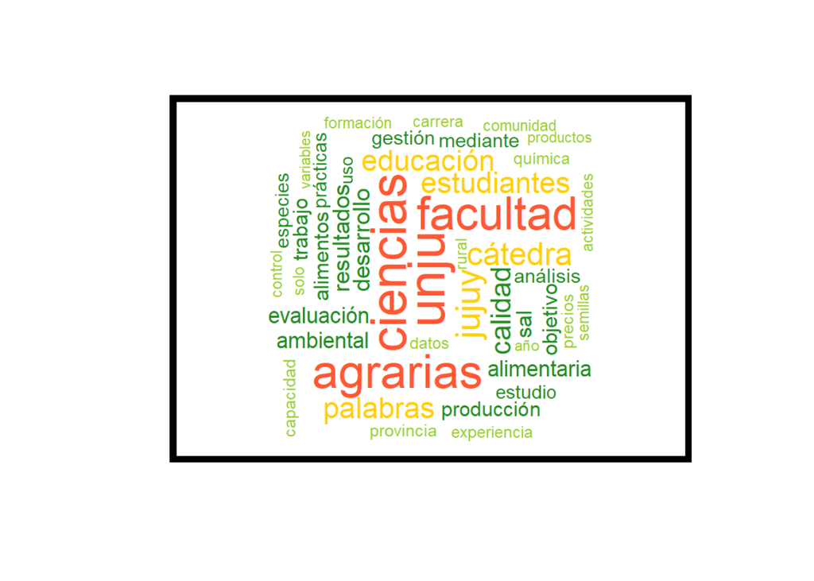

Contribuciones de los pósteres en palabras.

[interactive chart not shown]